# Orthopedic Materials Sales (100 points)

Student Name: Kabita Paul

13/10/2019

**Purpose:**

To perform cluster analysis to identify potential business for orthopedic material sales

**Description:**

**Instructions:**

Please follow these steps: 1. In Canvas, navigate to Assignments and then Assignment4 2. Download and save the data set hospital_ortho.csv 3. Read the file:

**Install.packages**

```r
library(dplyr)
library(cluster)
library(tidyverse)
library(tidytext)
library(clustertend)
library(dbscan)
library(data.table)
```

**Load Data**

```r
data <- fread("Data/hospital_ortho.csv", sep=",", header=T, strip.white = T, na.strings = c("NA","NaN","","?"))
##head(data)
#data
```

4. The original data includes hospitals across the US. However, we can only sell our products in NC and the nearby states of SC, VA, GA, and TN. Use the following code to narrow down the data to hospitals in these states.

```r
nc_data <- data[(data$state == "NC") | (data$state == "SC") | (data$state == "VA") | (data$state == "GA") | (data$state == "TN")]
nc_data
```

```
##        zip    hid         city state beds rbeds out-v   adm   sir salesy
##   1: 22033  23134      Fairfax    VA  156     0 22777  8734  8096     13
##   2: 22042  49034 Falls Church    VA  656    10 87126 39428 27048      3
##   3: 22205   4034    Arlington    VA  296     0 12896 14900  9777      9
##   4: 22206   3534    Arlington    VA  105    21 42610  2403  2805      1
##   5: 22304   2034   Alexandria    VA  347     0 44072 14780 10209      5
##  ---
## 505: 38358  88552        Milan    TN   72     0  7155  1440   724      1
## 506: 38363 111152      Parsons    TN   40     0 16695  1296   264      1
## 507: 38372 116552     Savannah    TN  132     0 24000  2792  1784      3
## 508: 38464  59052 Lawrenceburg    TN   86     0 10724  3353  2589      2
## 509: 38555  21552   Crossville    TN  184     0 49025  7389  6524      0
##      sales12 hip knee th trauma rehab hip12 knee12 femur12
##   1:      25  38   34  0      0     0    47     24      55
##   2:       5 148   84  1      1     1   169     68     265
##   3:      10 126   57  1      0     0   131     79      96
##   4:       1 335  215  1      0     1   185    180      47
##   5:       5  66   35  0      1     0    78     38      98
##  ---
## 505:       1   0    0  0      0     0     0      0       0
## 506:       2   0    0  0      0     0     0      0       8
## 507:       3   0    0  0      0     0     0      0       0
## 508:       5   3    0  0      0     0     0      0      32
## 509:       1  36   17  0      0     0    30     23      39
```

4.1. (3 points) Look at each individual variable and decide if it should be included in cluster analysis. For those variables that you decide not to include, give your reasons for exclusion.

```r
colnames(nc_data)
```

```
##  [1] "zip"     "hid"     "city"    "state"   "beds"    "rbeds"   "out-v"
##  [8] "adm"     "sir"     "salesy"  "sales12" "hip"     "knee"    "th"
## [15] "trauma"  "rehab"   "hip12"   "knee12"  "femur12"
```

Ans. Since cluster analysis relies on the distances among observations, we would consider numerical variables into consideration. We will not consider categorical values like ZIP, HID, CITY, STATE, TH, TRAUMA, REHAB

**Filtering columns**

```r
mydata  <- select(nc_data, c(beds, rbeds, `out-v`, adm, sir, salesy, sales12, hip, knee, hip12, knee12, femur12 ))
```

4.2. (3 points) Do you need to scale this data? Why?

```r
summary(mydata)
```

```
##       beds            rbeds             out-v             adm
##  Min.   :  12.0   Min.   :  0.000   Min.   :     0   Min.   :    0
##  1st Qu.:  78.0   1st Qu.:  0.000   1st Qu.: 10532   1st Qu.: 2385
##  Median : 128.0   Median :  0.000   Median : 21200   Median : 4653
##  Mean   : 198.4   Mean   :  7.578   Mean   : 48492   Mean   : 7064
##  3rd Qu.: 268.0   3rd Qu.:  0.000   3rd Qu.: 43195   3rd Qu.: 9301
##  Max.   :1412.0   Max.   :850.000   Max.   :984453   Max.   :46299
##       sir            salesy          sales12            hip
##  Min.   :    0   Min.   :  0.00   Min.   :  0.00   Min.   :  0.00
##  1st Qu.: 1395   1st Qu.:  0.00   1st Qu.:  0.00   1st Qu.:  8.00
##  Median : 3523   Median :  1.00   Median :  2.00   Median : 27.00
##  Mean   : 5101   Mean   : 26.48   Mean   : 39.62   Mean   : 48.04
##  3rd Qu.: 7379   3rd Qu.: 17.00   3rd Qu.: 25.00   3rd Qu.: 68.00
##  Max.   :36450   Max.   :633.00   Max.   :795.00   Max.   :361.00
##       knee            hip12            knee12          femur12
##  Min.   :  0.00   Min.   :  0.00   Min.   :  0.00   Min.   :  0.00
##  1st Qu.:  1.00   1st Qu.:  6.00   1st Qu.:  0.00   1st Qu.: 11.00
##  Median : 14.00   Median : 28.00   Median : 13.00   Median : 35.00
##  Mean   : 35.13   Mean   : 48.98   Mean   : 35.64   Mean   : 53.09
##  3rd Qu.: 47.00   3rd Qu.: 70.00   3rd Qu.: 49.00   3rd Qu.: 78.00
##  Max.   :549.00   Max.   :387.00   Max.   :377.00   Max.   :489.00
```

Ans.

As cluster analysis is dependant on the distances among points/observations, we need to standardize the data before cluster analysis. This process will assure that the differences in scales across variables will not impact the results. As an example,number of knee- surgery ranges from 0- 377 whereas number of out patient visit ranges from 0 to 984 K. Due to difference in scales, standardization is needed.

```r
#head(mydata)
```

**standardize the data**

```r
if (TRUE){
  df <- scale(mydata) # Standardize the data
} else{
  df <- mydata[]
}
head(df)
```

```
##            beds       rbeds       out-v         adm        sir     salesy
## [1,] -0.2305491 -0.18457225 -0.27078263  0.24016536  0.5824345 -0.1988357
## [2,]  2.4897784  0.05900378  0.40683480  4.65545067  4.2682321 -0.3463252
## [3,]  0.5311426 -0.18457225 -0.37483301  1.12713510  0.9093565 -0.2578315
## [4,] -0.5080225  0.32693742 -0.06193422 -0.67053938 -0.4465628 -0.3758232
## [5,]  0.8086160 -0.18457225 -0.04653885  1.10987328  0.9933721 -0.3168273
## [6,]  0.1666187  1.25252636 -0.25241770 -0.08708994  0.4888893 -0.1840867
##         sales12         hip         knee       hip12      knee12
## [1,] -0.1466933 -0.16707105 -0.020309865 -0.03286296 -0.21213613
## [2,] -0.3473569  1.66315942  0.881760060  1.99367524  0.58944998
## [3,] -0.2971910  1.29711333  0.394642301  1.36245843  0.78984650
## [4,] -0.3874896  4.77455122  3.245183266  2.25945075  2.62985098
## [5,] -0.3473569  0.29880580 -0.002268467  0.48207708  0.04291399
## [6,] -0.2269588  0.03259046  0.196186917  1.57840102  0.60766784
##         femur12
## [1,]  0.0327918
## [2,]  3.6314731
## [3,]  0.7353915
## [4,] -0.1043008
## [5,]  0.7696646
## [6,]  0.2041576
```

5. Perform k-means clustering:

```r
#k- means clustering
k.means.fit <- kmeans(df, 3) # Perform k-means clustering with 3 clusters
attributes(k.means.fit) # Check the attributes that k-means generates
```

```
## $names
## [1] "cluster"      "centers"      "totss"        "withinss"
## [5] "tot.withinss" "betweenss"    "size"         "iter"
## [9] "ifault"
##
## $class
## [1] "kmeans"
```

5.1. (3 points) Use “Within Groups SSE” to determine the number of clusters for k-means. How many clusters you would like to create?

Ans. By looking at the Within group SSE below, we can say 3 would be reasonable choice of clusters as we increase k after 3, the SSE does not decrease much.

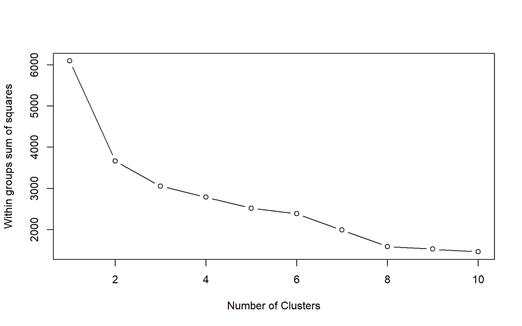

```r
withinssplot <- function(data, nc=15, seed=1234){
  wss <- (nrow(data)-1)*sum(apply(data,2,var))
  for (i in 2:nc){
    set.seed(seed)
    wss[i] <- sum(kmeans(data, centers=i)$withinss)}
  plot(1:nc, wss, type="b", xlab="Number of Clusters",
       ylab="Within groups sum of squares")}
withinssplot(df, nc=10)
```

```r
#k- means clustering
```

```r
#hopkins(df, n = nrow(df)-1)
```

5.2. (3 points) Paste the “Within Groups SSE” plot in the space below:

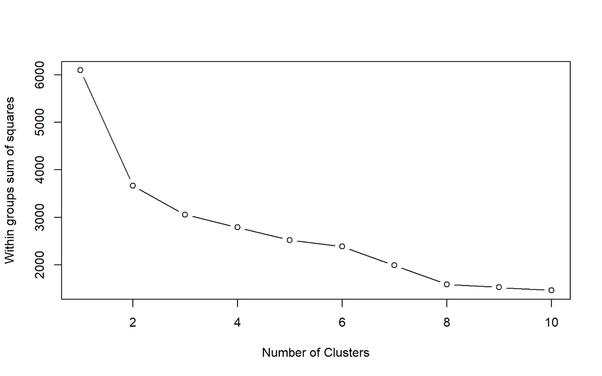

```r
withinssplot <- function(data, nc=15, seed=1234){
  wss <- (nrow(data)-1)*sum(apply(data,2,var))
  for (i in 2:nc){
    set.seed(seed)
    wss[i] <- sum(kmeans(data, centers=i)$withinss)}
  plot(1:nc, wss, type="b", xlab="Number of Clusters",
       ylab="Within groups sum of squares")}
withinssplot(df, nc=10)
```

5.3. (3 points) Perform k-means clustering using the number of clusters you recommended in 5.1. How many hospitals fall in each cluster?

```r
k.means.fit <- kmeans(df, 3) # Perform k-means clustering with 3 clusters
k.means.fit$size # checking how many hospitals fall in each group
```

```
## [1] 338 124  47
```

```r
attributes(k.means.fit) # Check the attributes that k-means generates
```

```
## $names
## [1] "cluster"      "centers"      "totss"        "withinss"
## [5] "tot.withinss" "betweenss"    "size"         "iter"
## [9] "ifault"
##
## $class
## [1] "kmeans"
```

```r
k.means.fit$centers
```

```
##         beds        rbeds      out-v        adm        sir      salesy
## 1 -0.4695194  0.004883782 -0.1928189 -0.5219405 -0.5264345 -0.25804967
## 2  0.5742291 -0.050801866  0.2767133  0.6554374  0.7211917  0.03786133
## 3  1.8615564  0.098908793  0.6566030  2.0242905  1.8831295  1.75587202
##       sales12        hip       knee      hip12     knee12    femur12
## 1 -0.27659035 -0.5155434 -0.4529298 -0.5243117 -0.4632516 -0.5226767
## 2  0.03495573  0.5550917  0.4409098  0.5805373  0.4369488  0.6546837
## 3  1.89687296  2.2430274  2.0939885  2.2389521  2.1786681  2.0315731
```

```r
k.means.fit$cluster
```

```
##   [1] 1 3 2 2 2 2 2 3 1 2 3 1 2 1 1 3 3 3 2 2 3 2 2 3 2 3 1 2 2 2 2 3 1 2 3
##  [36] 2 2 1 2 1 1 3 3 1 1 2 2 3 2 2 1 2 2 3 3 3 2 3 2 2 1 2 3 2 3 1 2 3 3 1
##  [71] 2 1 2 2 1 2 1 2 3 2 1 1 2 2 2 3 1 2 3 2 2 2 2 2 3 1 1 2 1 2 2 3 2 1 1
## [106] 1 2 2 2 2 3 1 1 1 1 2 1 2 2 2 1 1 2 1 3 3 3 2 3 2 2 2 1 1 2 1 2 2 2 2
## [141] 2 2 2 2 1 3 1 1 2 3 2 2 2 2 2 2 2 1 2 2 3 1 1 2 2 2 3 1 2 1 3 3 1 3 2
## [176] 2 1 3 3 2 2 1 3 3 2 2 2 1 3 2 3 1 3 3 2 2 2 2 2 2 2 2 2 2 2 2 2 2 2 2
## [211] 2 2 1 2 1 2 1 1 1 1 1 2 1 1 1 1 1 1 1 1 1 1 1 1 1 1 1 1 1 1 1 1 1 1 1
## [246] 1 2 1 1 1 1 1 1 1 1 1 1 2 1 1 1 1 1 1 1 1 1 1 1 1 1 1 1 1 1 1 1 1 1 1
## [281] 1 1 1 1 1 1 1 1 1 1 1 1 1 1 1 1 1 1 1 1 1 1 1 1 1 1 1 1 1 1 1 1 1 1 1
## [316] 1 1 1 2 1 1 1 1 1 1 1 1 1 1 1 1 1 1 1 1 1 1 1 1 1 1 1 1 1 1 1 1 1 2 1
## [351] 1 1 2 1 1 1 1 1 1 1 1 1 1 1 1 1 1 1 1 1 1 1 1 1 1 1 1 1 1 1 1 1 1 1 1
## [386] 1 1 1 1 1 1 1 1 1 1 1 1 1 1 1 1 1 1 1 1 1 1 1 1 1 1 1 1 1 1 1 1 1 1 1
## [421] 1 2 1 1 1 1 1 1 1 1 1 1 1 1 1 1 1 1 1 1 1 1 1 2 1 1 1 1 1 1 1 1 1 1 1
## [456] 1 1 1 1 1 1 1 1 1 1 1 1 1 1 1 1 1 1 1 1 1 1 1 1 1 1 1 1 1 1 1 1 1 1 1
## [491] 1 1 1 1 2 1 1 1 1 1 1 1 1 1 1 1 1 1 1
```

```r
#nc_data$kmeans <- k.means.fit$cluster
```

```r
#nc_data
```

5.4. (3 points) Create a two-dimensional representation of the clusters and paste it below:

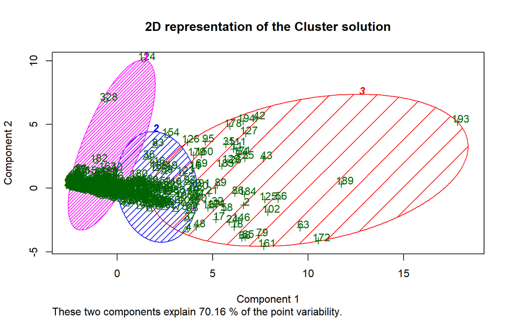

```r
# To create the clusters in 2-dimensional space:
clusplot(df, k.means.fit$cluster, main='2D representation of the Cluster solution', color=TRUE, shade=TRUE, labels=2, lines=0)
```

6. Perform Hierarchical clustering.

6.1. (4 points) Try different hierarchical clustering and paste the dendrograms in the space below:

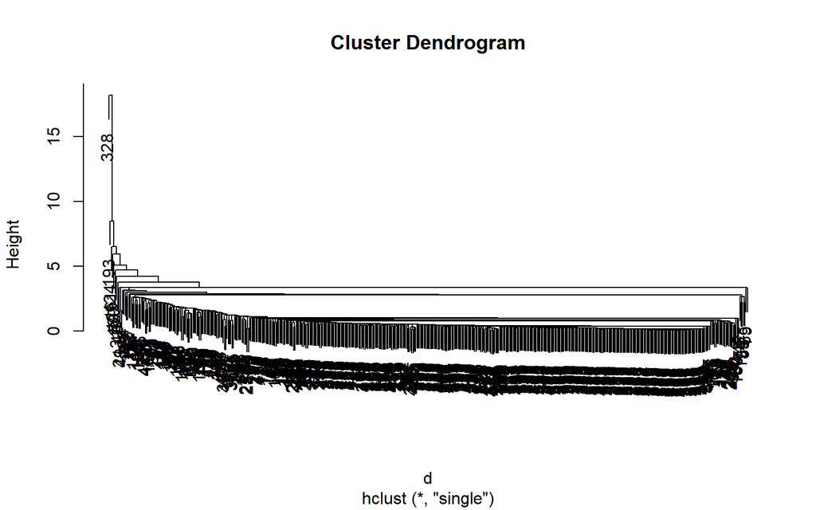

```r
df <- df[complete.cases(df),]
d <- dist(df, method = "euclidean") # Euclidean distance matrix.
H.single <- hclust(d, method="single")
plot(H.single) # display dendogram
```

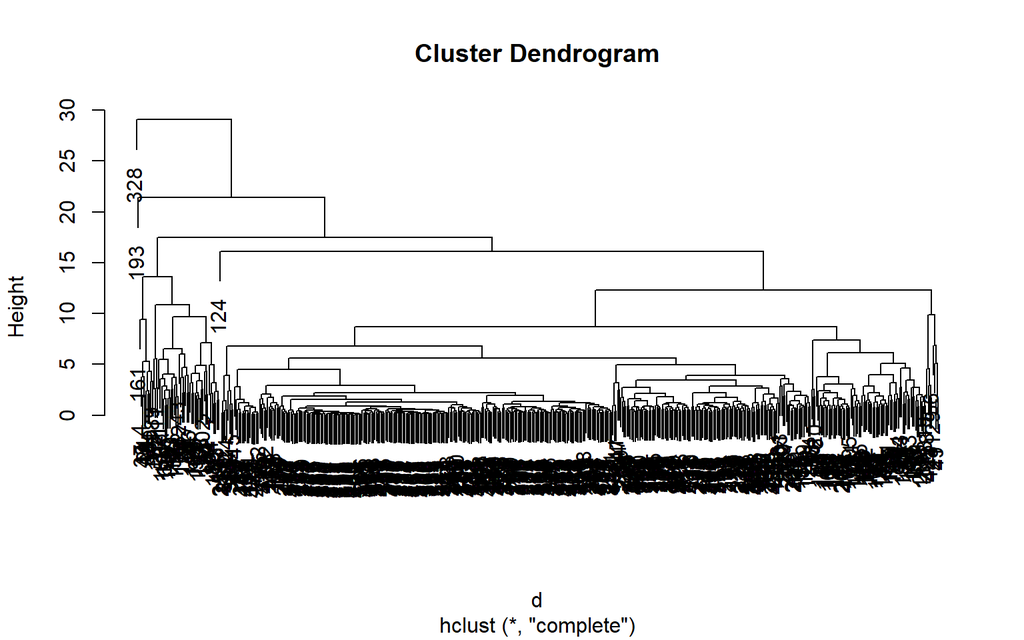

```r
H.complete <- hclust(d, method="complete")
plot(H.complete)
```

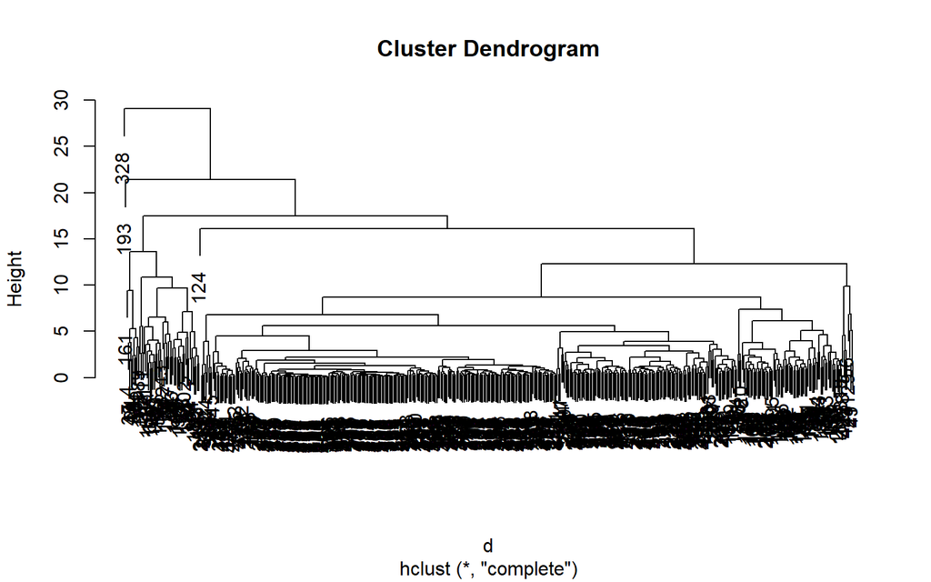

```r
H.average <- hclust(d, method="average")
plot(H.complete)
```

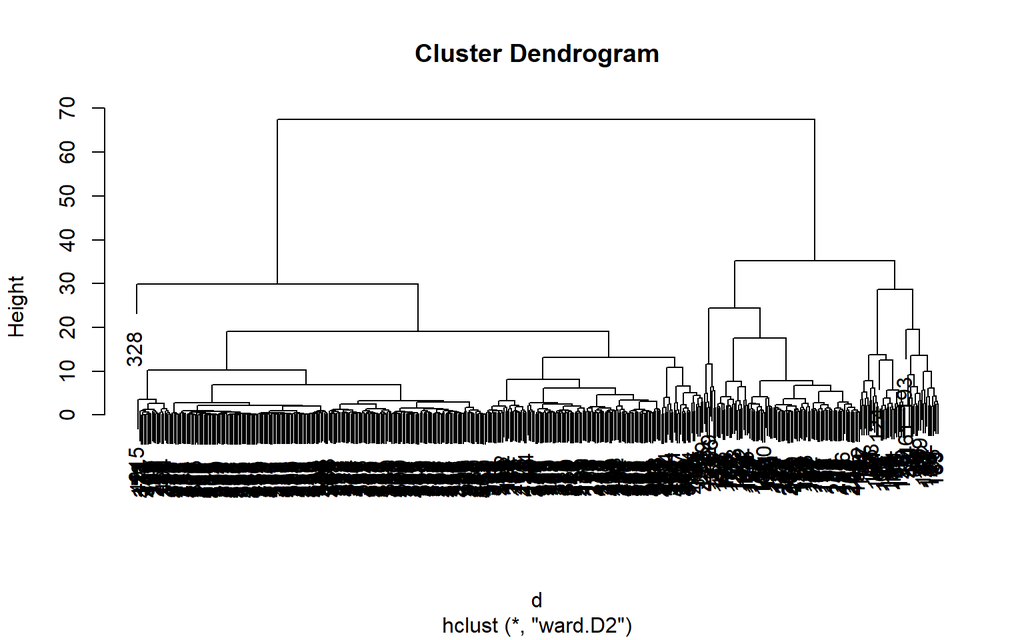

```r
H.ward <- hclust(d, method="ward.D2")
plot(H.ward)
```

6.2. (3 points) Determine which hierarchical clustering method would be more appropriate for this data. Why?

Ans. After visually inspecting the outputs of clustering, we would go for Ward alogorithm in this case, as it makes clear seperation between clusters.

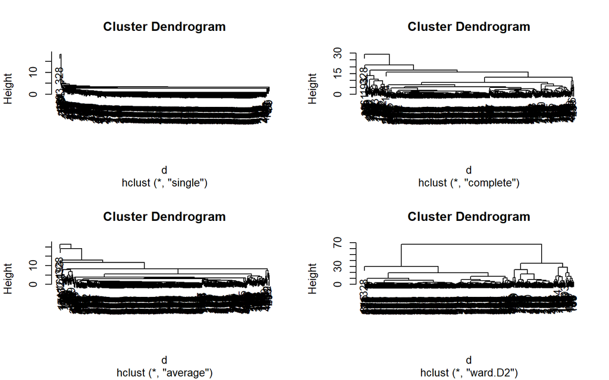

```r
par(mfrow=c(2,2))
plot(H.single)
plot(H.complete)
plot(H.average)
plot(H.ward)
```

6.3. (3 points) Based on hierarchical clustering results, how many clusters do you find in this data?

Ans. We can see three major clusters in the dendogram.

```r
par(mfrow=c(1,1))
groups <- cutree(H.ward, k=3) # cut tree into 3 clusters
```

6.4. (3 points) Paste the dendrogram that you chose with the red borders around the clusters in the space below:

Ans.

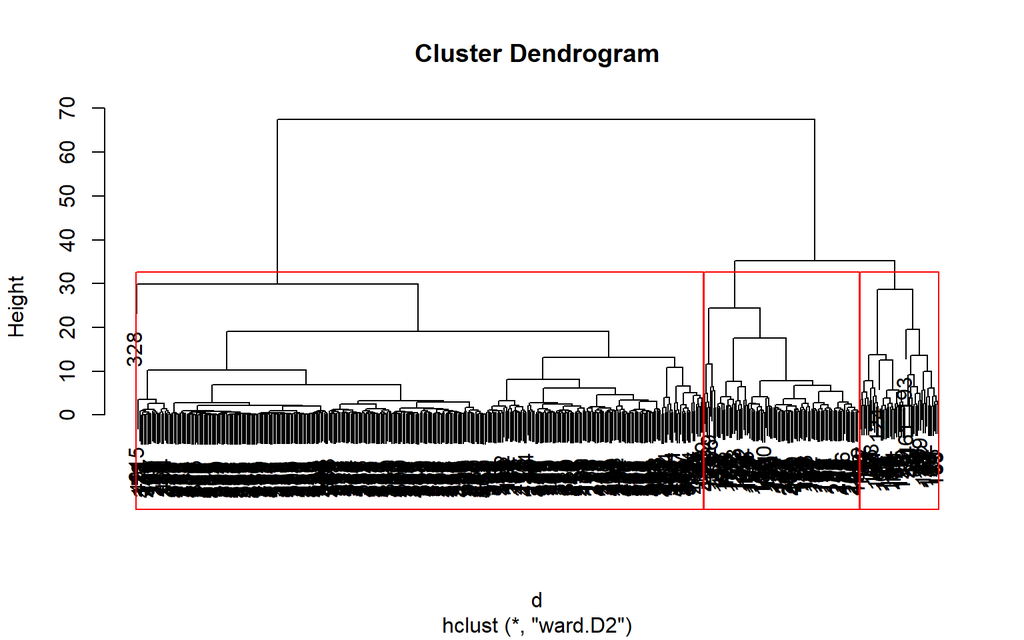

```r
plot(H.ward)
rect.hclust(H.ward, k=3, border="red")
```

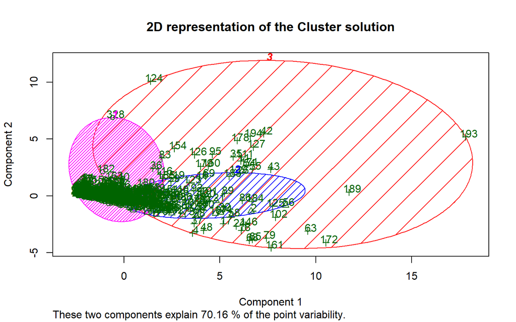

```r
clusplot(df, groups, main='2D representation of the Cluster solution',
         color=TRUE, shade=TRUE,
         labels=2, lines=0)
```

```r
#nc_data$hclust <- groups
```

7. Perform DBSCAN cluster analysis: 7.1. (7 points) First, you need to determine minPts. The rule of thumb for minPts is the number of dimensions of the data + 1. Suggest a method to determine the number of dimensions of this data? Implement your method and suggest a good minPts.

Ans. I would recommend minPts =6 based on PCA

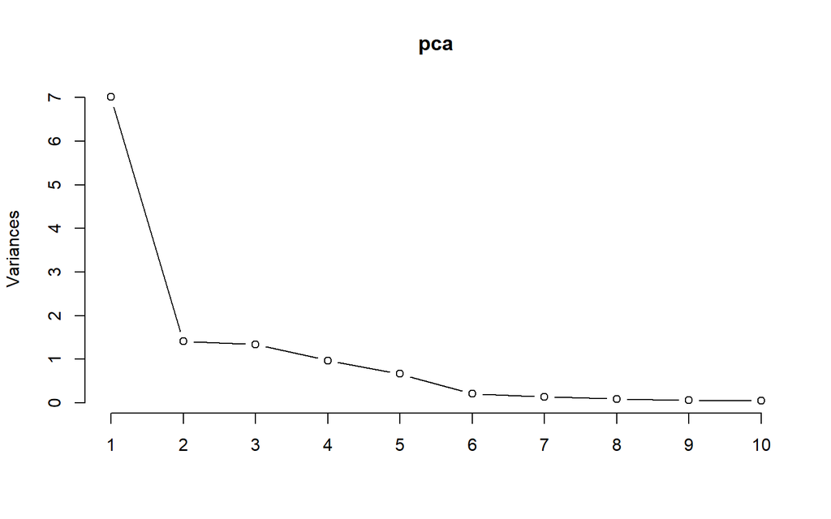

```r
data <- nc_data[complete.cases(nc_data),]
mydata  <- select(data, c(beds, rbeds, `out-v`, adm, sir, salesy, sales12, hip, knee, hip12, knee12, femur12 ))
pca <- prcomp(mydata, center = TRUE, scale. = TRUE)

plot(pca, type = "l")
```

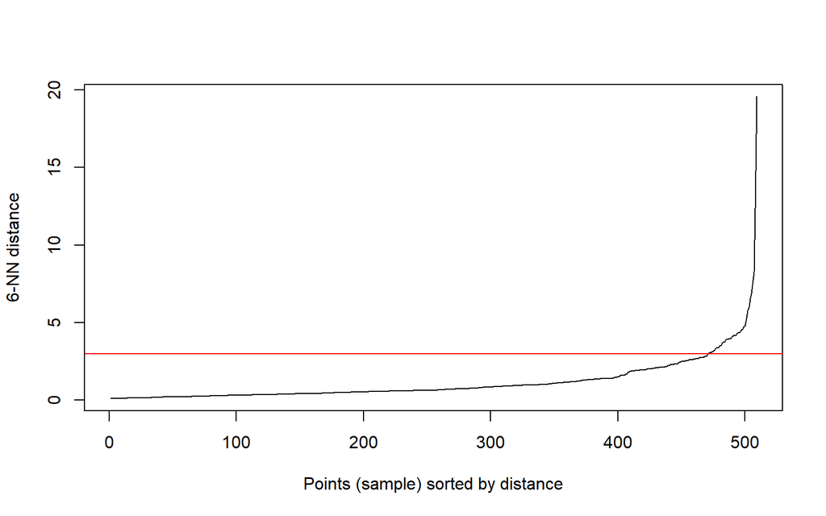

```r
library(dbscan)
kNNdistplot(df, k =6)
abline(h=3, col="red")
```

7.2. (3 points) Based on your suggested minPts, determine the eps. Explain your recommendation for eps.

Ans. eps= 3

After determining minPts and eps, we can run the dbscan algorithm and plot the results:

```r
db <- dbscan(df, eps=3, minPts=6)
db
```

```
## DBSCAN clustering for 509 objects.
## Parameters: eps = 3, minPts = 6
## The clustering contains 1 cluster(s) and 24 noise points.
##
##   0   1
##  24 485
##
## Available fields: cluster, eps, minPts
```

```r
db$cluster
```

```
##   [1] 1 1 1 0 1 1 1 1 1 1 0 1 1 1 1 1 1 1 1 1 0 1 1 0 1 1 1 1 1 1 1 1 1 1 1
##  [36] 1 1 1 1 1 1 0 0 1 1 1 1 1 0 1 1 1 1 1 1 0 1 1 1 1 1 1 0 1 0 1 1 0 1 1
##  [71] 1 1 1 1 1 1 1 1 0 1 1 1 1 1 1 1 1 1 1 1 1 1 1 1 1 1 1 1 1 1 1 1 1 1 1
## [106] 1 1 1 1 1 1 1 1 1 1 1 1 1 1 1 1 1 1 0 0 1 0 1 0 1 1 1 1 1 1 1 1 1 1 1
## [141] 1 1 1 1 1 1 1 1 1 1 1 1 1 1 1 1 1 1 1 1 0 1 1 1 1 1 1 1 1 1 1 0 1 1 1
## [176] 1 1 0 1 1 1 1 1 1 1 1 1 1 0 1 1 1 0 1 1 1 1 1 1 1 1 1 1 1 1 1 1 1 1 1
## [211] 1 1 1 1 1 1 1 1 1 1 1 1 1 1 1 1 1 1 1 1 1 1 1 1 1 1 1 1 1 1 1 1 1 1 1
## [246] 1 1 1 1 1 1 1 1 1 1 1 1 0 1 1 1 1 1 1 1 1 1 1 1 1 1 1 1 1 1 1 1 1 1 1
## [281] 1 1 1 1 1 1 1 1 1 1 1 1 1 1 1 1 1 1 1 1 1 1 1 1 1 1 1 1 1 1 1 1 1 1 1
## [316] 1 1 1 0 1 1 1 1 1 1 1 1 0 1 1 1 1 1 1 1 1 1 1 1 1 1 1 1 1 1 1 1 1 1 1
## [351] 1 1 1 1 1 1 1 1 1 1 1 1 1 1 1 1 1 1 1 1 1 1 1 1 1 1 1 1 1 1 1 1 1 1 1
## [386] 1 1 1 1 1 1 1 1 1 1 1 1 1 1 1 1 1 1 1 1 1 1 1 1 1 1 1 1 1 1 1 1 1 1 1
## [421] 1 1 1 1 1 1 1 1 1 1 1 1 1 1 1 1 1 1 1 1 1 1 1 1 1 1 1 1 1 1 1 1 1 1 1
## [456] 1 1 1 1 1 1 1 1 1 1 1 1 1 1 1 1 1 1 1 1 1 1 1 1 1 1 1 1 1 1 1 1 1 1 1
## [491] 1 1 1 1 1 1 1 1 1 1 1 1 1 1 1 1 1 1 1
```

7.3. (3 points) Perform DBSCAN clustering using the minPts and eps that you recommended. How many clusters DBSCAN returns?

7.4. (3 points) How many noise points it returns?

7.5. (3 points) Create a two-dimensional representation of DBSCAN cluster(s) and paste it in the space below:

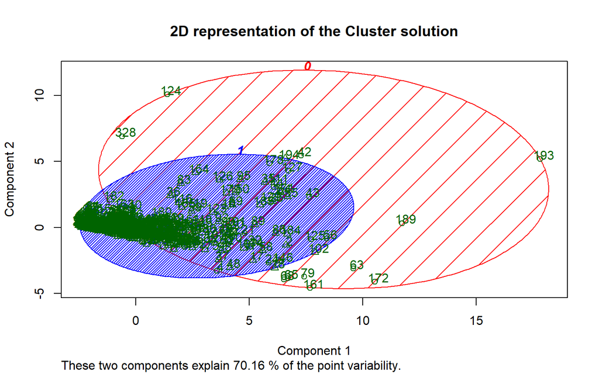

```r
clusplot(df, db$cluster, main='2D representation of the Cluster solution',
         color=TRUE, shade=TRUE,labels=2, lines=0)
```

```r
#hullplot(df, db)
```

```r
#nc_data$db <- db$cluster
```

8. Perform principal component analysis on the original data (nc_data). Then select the number of principal components based on PCs variance plot. Let’s call the number of PCs n_pc. Then we can use the best PCs instead of the data to perform cluster analysis. To do this, run:

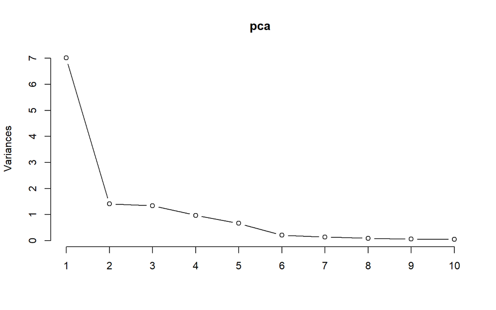

```r
data <- nc_data[complete.cases(nc_data),]
mydata  <- select(data, c(beds, rbeds, `out-v`, adm, sir, salesy, sales12, hip, knee, hip12, knee12, femur12 ))
pca <- prcomp(mydata, center = TRUE, scale. = TRUE)

plot(pca, type = "l")
```

```r
summary(pca)
```

```
## Importance of components:
##                           PC1    PC2    PC3     PC4    PC5     PC6     PC7
## Standard deviation     2.6476 1.1872 1.1571 0.98627 0.8154 0.45574 0.37531
## Proportion of Variance 0.5842 0.1175 0.1116 0.08106 0.0554 0.01731 0.01174
## Cumulative Proportion  0.5842 0.7016 0.8132 0.89426 0.9497 0.96697 0.97871
##                            PC8     PC9    PC10    PC11    PC12
## Standard deviation     0.29731 0.25274 0.22008 0.18243 0.14663
## Proportion of Variance 0.00737 0.00532 0.00404 0.00277 0.00179
## Cumulative Proportion  0.98608 0.99140 0.99543 0.99821 1.00000
```

```r
n_pc <-4
pca_data <- predict(pca, newdata = nc_data)
pc_df <- as.data.frame(scale(pca_data[,c(1:n_pc)]))  # replace n_pc with the number of PCs you recommend.
#pc_df
```

8.1. (10 points) Repeat your analysis in question 5 using the new pc_df. What is the best k? Paste the two-dimensional representation in the space below:

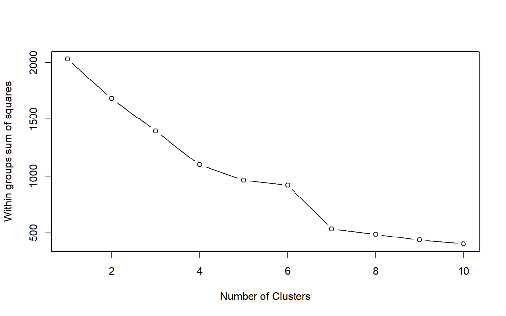

```r
withinssplot <- function(pc_df, nc=15, seed=1234){
  wss <- (nrow(pc_df)-1)*sum(apply(pc_df,2,var))
  for (i in 2:nc){
    set.seed(seed)
    wss[i] <- sum(kmeans(pc_df, centers=i)$withinss)}
  plot(1:nc, wss, type="b", xlab="Number of Clusters",
       ylab="Within groups sum of squares")}
withinssplot(pc_df, nc=10)
```

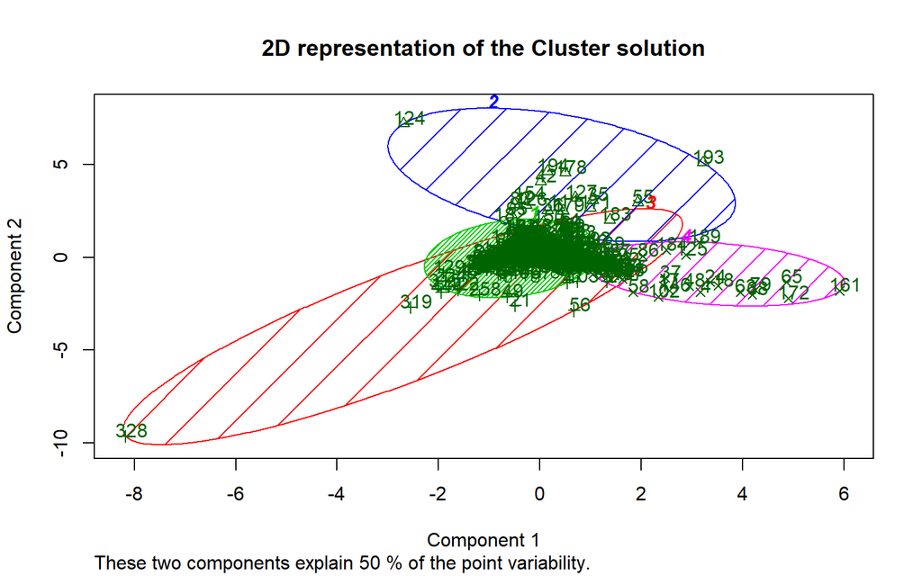

```r
k.means.fit <- kmeans(pc_df, 4)
# To create the clusters in 2-dimensional space:
library(cluster)
clusplot(pc_df, k.means.fit$cluster, main='2D representation of the Cluster solution', color=TRUE, shade=TRUE, labels=2, lines=0)
```

8.2. (10 points) Repeat your analysis in question 6 using the new pc_df. What is the best method? What is the best k? Paste the dendrogram in the space below:

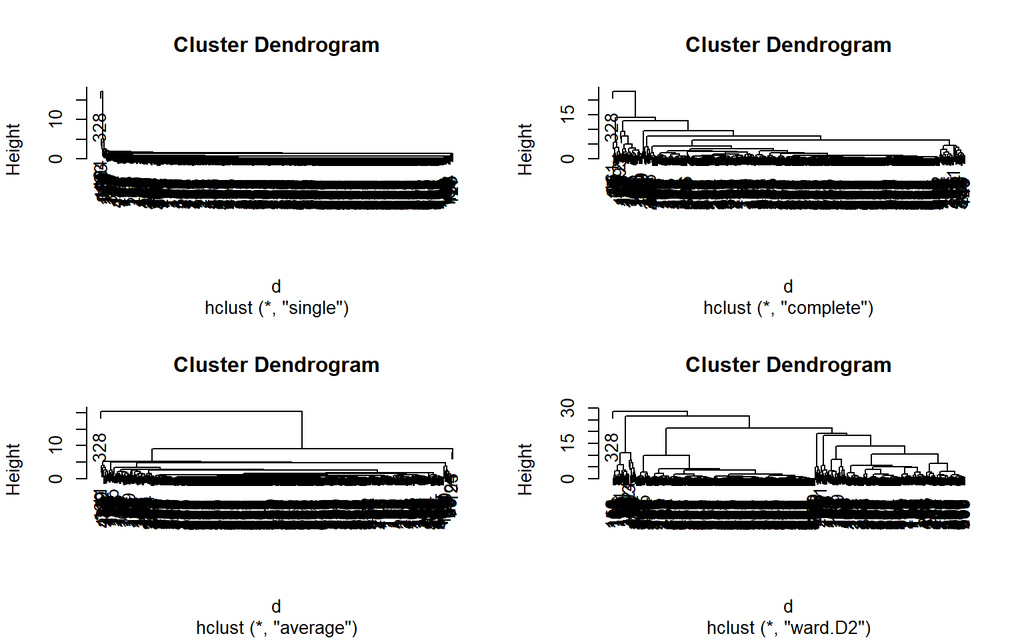

```r
#df
d <- dist(pc_df, method = "euclidean") # Euclidean distance matrix.
H.single <- hclust(d, method="single")
H.average <- hclust(d, method="average")
H.complete <- hclust(d, method="complete")
H.ward <- hclust(d, method="ward.D2")


par(mfrow=c(2,2))
plot(H.single)
plot(H.complete)
plot(H.average)
plot(H.ward)
```

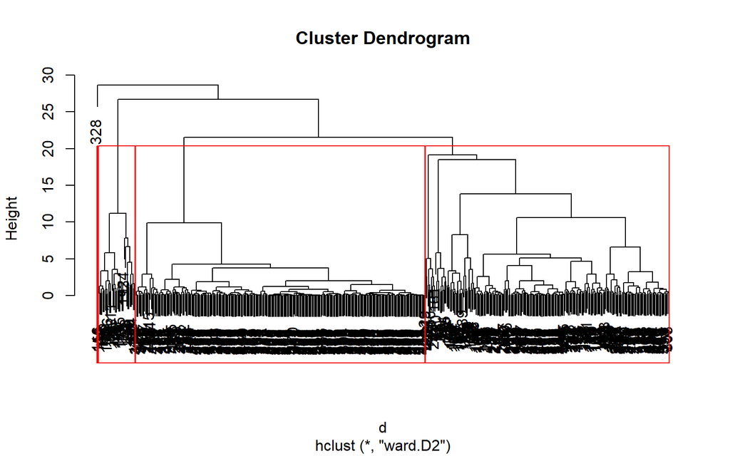

```r
par(mfrow=c(1,1))
groups <- cutree(H.ward, k=4) # cut tree into 3 clusters

plot(H.ward)
rect.hclust(H.ward, k=4, border="red")
```

8.3. (10 points) Repeat your analysis in question 7 using the new pc_df. What is the best minPts? What is the best eps? How many clusters DBSCAN returns? Perform the DBSCAN clustering and paste the two-dimensional representation in the space below:

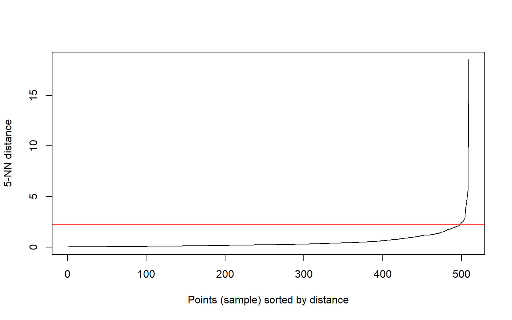

```r
kNNdistplot(pc_df, k =5)
abline(h=2.2, col="red")
```

```r
db <- dbscan(pc_df, eps=2.2, minPts=5)
db
```

```
## DBSCAN clustering for 509 objects.
## Parameters: eps = 2.2, minPts = 5
## The clustering contains 1 cluster(s) and 5 noise points.
##
##   0   1
##   5 504
##
## Available fields: cluster, eps, minPts
```

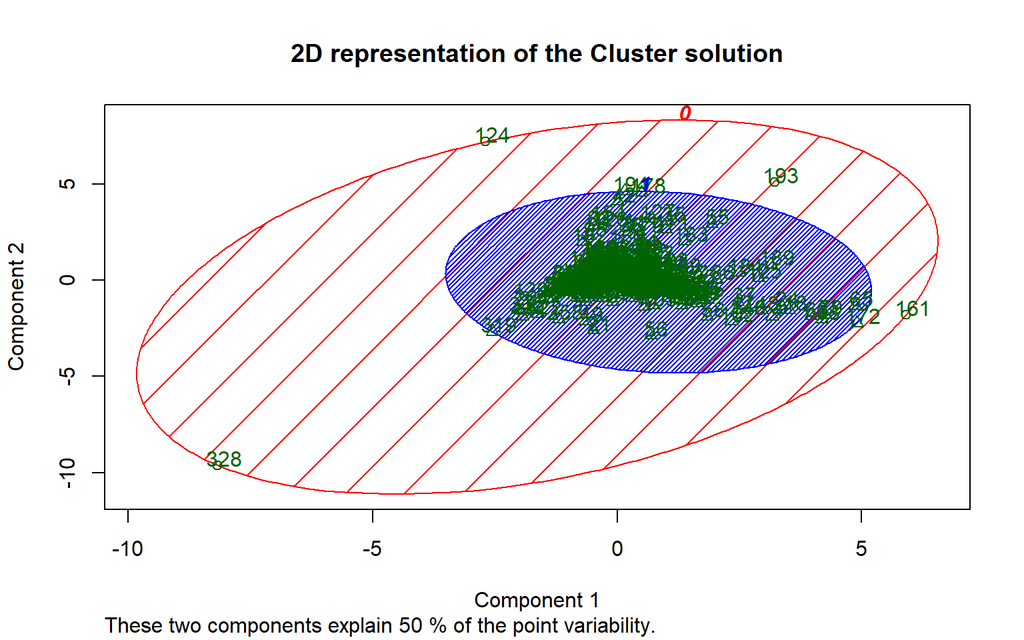

```r
clusplot(pc_df, db$cluster, main='2D representation of the Cluster solution',
         color=TRUE, shade=TRUE,
         labels=2, lines=0)
```

```r
#hullplot(pc_df, db)
```

9. For each hospital, determine the cluster (based on pc_df) to which they belong. Then determine the value of “sales12”,“rbeds”,“hip12”,“knee12”, and “femur12” for each cluster for each clustering method (e.g. k-means, hierarchical, DBSCAN). To do this, you need to run the following lines:

```r
pc_df$kmeans <- k.means.fit$cluster
pc_df $hclust <- groups # these groups are created in hierarchical clustering
pc_df $db <- db$cluster
pc_df $hid <- nc_data$hid # Add hospital id to pc_df data
final_data <- merge(x=pc_df, y=nc_data, key="hid")
aggregate(final_data[,c("sales12","rbeds","hip12","knee12","femur12")], list(final_data$kmeans), mean)
```

```
##   Group.1   sales12     rbeds     hip12    knee12   femur12
## 1       1  16.52913  5.133495  28.84951  18.30097  35.05583
## 2       2 421.56522 18.826087 138.65217  96.86957 144.86957
## 3       3  30.13793 36.965517  75.51724  36.96552 107.68966
## 4       4  61.93333  5.266667 170.33333 162.28889 136.06667
```

```r
aggregate(final_data[,c("sales12","rbeds","hip12","knee12","femur12")], list(final_data$hclust), mean)
```

```
##   Group.1    sales12      rbeds     hip12    knee12   femur12
## 1       1   9.821705   5.837209  12.89147  5.368217  18.53876
## 2       2  27.866359   4.718894  81.56221 65.133641  83.51613
## 3       3 351.090909  14.454545 118.33333 79.515152 124.69697
## 4       4   0.000000 850.000000   0.00000  0.000000   0.00000
```

```r
aggregate(final_data[,c("sales12","rbeds","hip12","knee12","femur12")], list(final_data$db), mean)
```

```
##   Group.1   sales12      rbeds     hip12    knee12  femur12
## 1       0 342.20000 193.600000 117.60000 122.80000 180.2000
## 2       1  36.61905   5.732143  48.29762  34.77976  51.8254
```

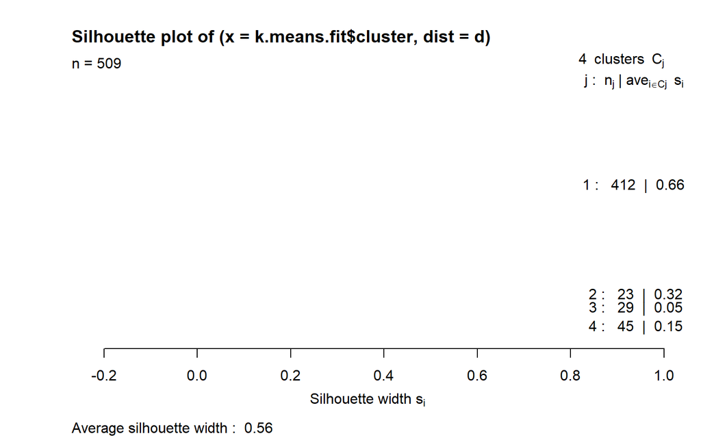

```r
plot(silhouette(k.means.fit$cluster, d)) # d is the distance
```

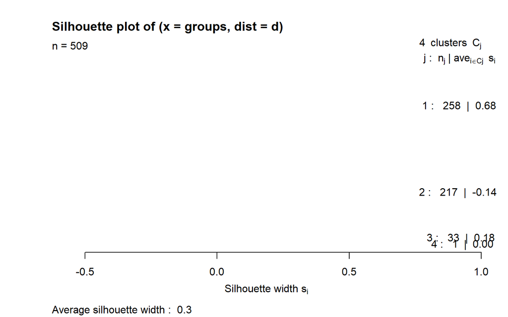

```r
plot(silhouette(groups, d)) # d is the distance
```

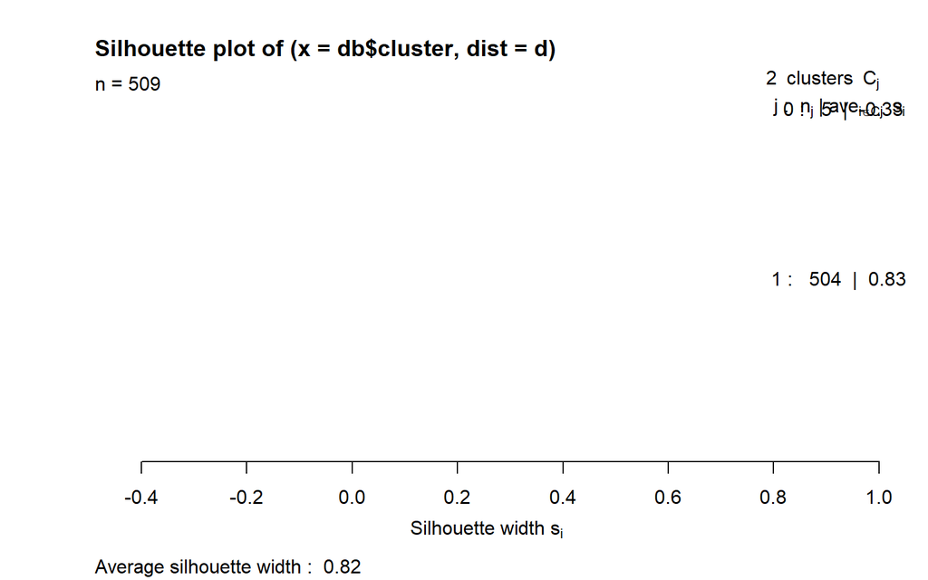

```r
plot(silhouette(db$cluster, d)) # d is the distance
```

9.1. (20 points) Based on these results for each clustering method (e.g. k-means, hierartchical, and DBSCAN), recommend which cluster we should immediately reach out to. Give your reasons.